# 3MDAN1_10Clase11

Rossy Cañari

2023-11-02

# Pasos

1. Carga de la data
2. Limpieza de datos
3. Manejar NAs
4. Seleccionar variables
5. Graficar base de datos
6. Cálculo de las Distancia de Mahalanobis y gráfico de barras
7. Cálculo del valor umbral y gráfico de barras
8. Gráfico Ojiva
9. QQ plot
10. Identificar valor máximo de Mahalanobis y eliminarlo
11. Cálculo de la distancia de Mahalanabis y gráfico de barras nuevamente
12. Gráfico de Ojiva Nuevamente

# 1. Carga de data

```r
dfe <- read.delim("DatosEmpresa.dat")
head(dfe)
```

```
##    ID SALINIT GENERO TTRABAJO EDAD SALACTUAL EXPACAD EXPTRAB CATTRAB MINORIA
## 1 628    8400      0       81   28     16080      16    0.25       4       0
## 2 630   24000      0       73   40     41400      16   12.50       5       0
## 3 632   10200      0       83   31     21960      15    4.08       5       0
## 4 633    8700      0       93   31     19200      16    1.83       4       0
## 5 635   17400      0       83   41     28350      19   13.00       5       0
## 6 637   12996      0       80   29     27250      18    2.42       4       0
```

# 2. Limpieza de datos

```r
library(dplyr)

dfe <- dfe %>%
  #Codificar los valores
  mutate(
    GENERO = case_when(
      GENERO == 0 ~ "Hombre",
      GENERO == 1 ~ "Mujer",
      TRUE ~ NA
    ),
    MINORIA = case_when(
      MINORIA == 0 ~ "Blanco",
      MINORIA == 1 ~ "No blanco",
      TRUE ~ NA
    ),
    CATTRAB = case_when(
      CATTRAB == 0 ~ NA,
      CATTRAB == 1 ~ "Oficinista",
      CATTRAB == 2 ~ "Asistente",
      CATTRAB == 3 ~ "Seguridad",
      CATTRAB == 4 ~ "Académico",
      CATTRAB == 5 ~ "Empleado",
      CATTRAB == 6 ~ "Ejecutivo",
      TRUE ~ "Técnico"
    )
  ) %>%
  # Convirtiendo en factores
  mutate(
    GENERO = factor(GENERO, levels = c("Hombre", "Mujer", NA)),
    MINORIA = factor(MINORIA, levels = c("Blanco", "No blanco", NA)),
    CATTRAB = factor(CATTRAB, levels = c(NA, "Oficinista", "Asistente", "Seguridad", "Académico", "Empleado", "Ejecutivo", "Técnico"))
  ) %>%
  # Reemplazar por NA
  mutate(
    SALINIT = ifelse(SALINIT == 0, NA, SALINIT),
    TTRABAJO = ifelse(TTRABAJO == 0, NA, TTRABAJO),
    EDAD = ifelse(EDAD == 0, NA, EDAD),
    SALACTUAL = ifelse(SALACTUAL == 0, NA, SALACTUAL),
    EXPACAD = ifelse(EXPACAD == 0, NA, EXPACAD),
    EXPTRAB = ifelse(EXPTRAB == 0, NA, EXPTRAB)
  )
head(dfe)
```

```
##    ID SALINIT GENERO TTRABAJO EDAD SALACTUAL EXPACAD EXPTRAB   CATTRAB MINORIA
## 1 628    8400 Hombre       81   28     16080      16    0.25 Académico  Blanco
## 2 630   24000 Hombre       73   40     41400      16   12.50  Empleado  Blanco
## 3 632   10200 Hombre       83   31     21960      15    4.08  Empleado  Blanco
## 4 633    8700 Hombre       93   31     19200      16    1.83 Académico  Blanco
## 5 635   17400 Hombre       83   41     28350      19   13.00  Empleado  Blanco
## 6 637   12996 Hombre       80   29     27250      18    2.42 Académico  Blanco
```

# 3. Manejar NAs

Primero evaluamos la distribución de los NAs

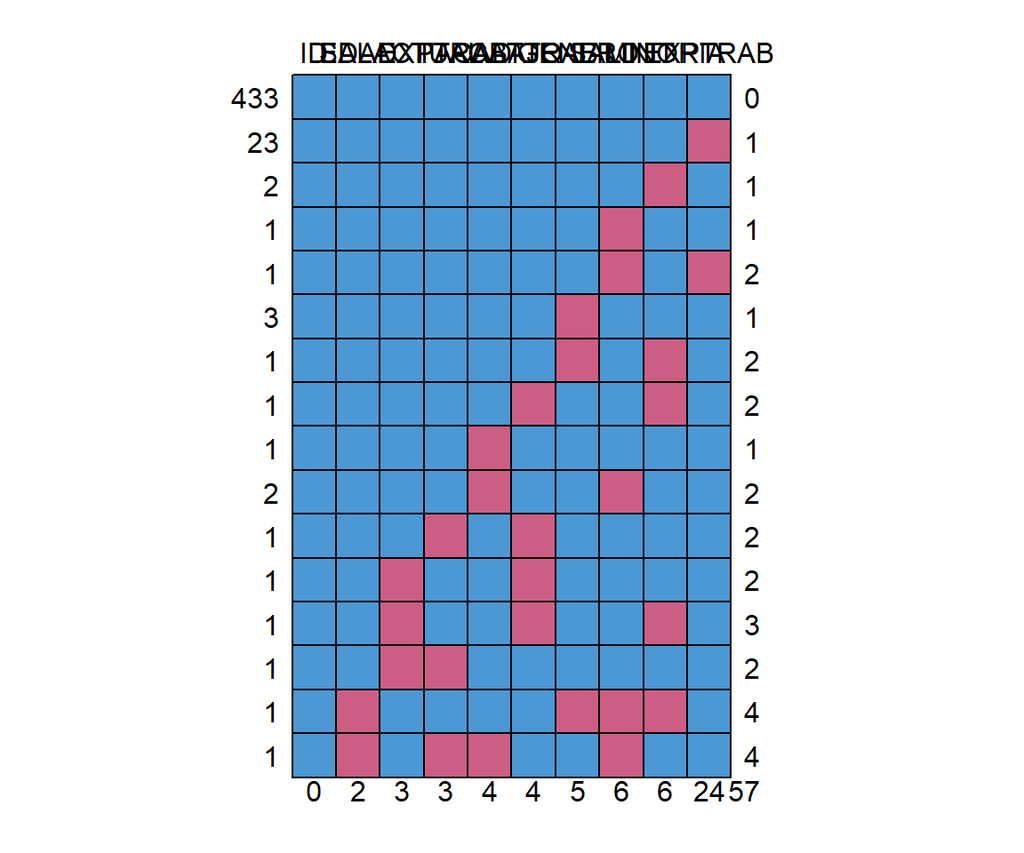

```
##     ID EDAD SALACTUAL EXPACAD TTRABAJO CATTRAB GENERO SALINIT MINORIA EXPTRAB
## 433  1    1         1       1        1       1      1       1       1       1  0
## 23   1    1         1       1        1       1      1       1       1       0  1
## 2    1    1         1       1        1       1      1       1       0       1  1
## 1    1    1         1       1        1       1      1       0       1       1  1
## 1    1    1         1       1        1       1      1       0       1       0  2
## 3    1    1         1       1        1       1      0       1       1       1  1
## 1    1    1         1       1        1       1      0       1       0       1  2
## 1    1    1         1       1        1       0      1       1       0       1  2
## 1    1    1         1       1        0       1      1       1       1       1  1
## 2    1    1         1       1        0       1      1       0       1       1  2
## 1    1    1         1       0        1       0      1       1       1       1  2
## 1    1    1         0       1        1       0      1       1       1       1  2
## 1    1    1         0       1        1       0      1       1       0       1  3
## 1    1    1         0       0        1       1      1       1       1       1  2
## 1    1    0         1       1        1       1      0       0       0       1  4
## 1    1    0         1       0        0       1      1       0       1       1  4
##      0    2         3       3        4       4      5       6       6      24 57
```

```r
library(mice)
md.pattern(dfe)
```

Vemos cuántos filas tiene al menos un NA

```r
dfe %>%
  rowwise() %>%
  mutate(TotalNa = ifelse(sum(is.na(across(everything()))) == 0, "No", "Al menos un NA")) %>%
  ungroup() %>%
  group_by(TotalNa) %>%
  summarise(Total1 = n())
```

```
## # A tibble: 2 × 2
##   TotalNa        Total1
##   <chr>           <int>
## 1 Al menos un NA     41
## 2 No                433
```

Número de NAs por columna

```r
dfe %>%
  summarise(across(everything(), ~sum(is.na(.))))
```

```
##   ID SALINIT GENERO TTRABAJO EDAD SALACTUAL EXPACAD EXPTRAB CATTRAB MINORIA
## 1  0       6      5        4    2         3       3      24       4       6
```

Eliminar los registros que tiene al menos un NA

```r
dfe <- dfe %>%
  na.omit()
```

Validar los resultados

```r
dfe %>%
  summarise(across(everything(), ~sum(is.na(.))))
```

```
##   ID SALINIT GENERO TTRABAJO EDAD SALACTUAL EXPACAD EXPTRAB CATTRAB MINORIA
## 1  0       0      0        0    0         0       0       0       0       0
```

# 4. Seleccionar variables

Solo se deben seleccionar **VARIABLES NUMÉRICAS**

```r
df <- dfe %>%
  dplyr::select(c(2,4,5,6,7,8))

head(df)
```

```
##   SALINIT TTRABAJO EDAD SALACTUAL EXPACAD EXPTRAB
## 1    8400       81   28     16080      16    0.25
## 2   24000       73   40     41400      16   12.50
## 3   10200       83   31     21960      15    4.08
## 4    8700       93   31     19200      16    1.83
## 5   17400       83   41     28350      19   13.00
## 6   12996       80   29     27250      18    2.42
```

# 5. Graficar base de datos

Se grafica todos los gráficos de dispersiones entre las variables de las bases de datos

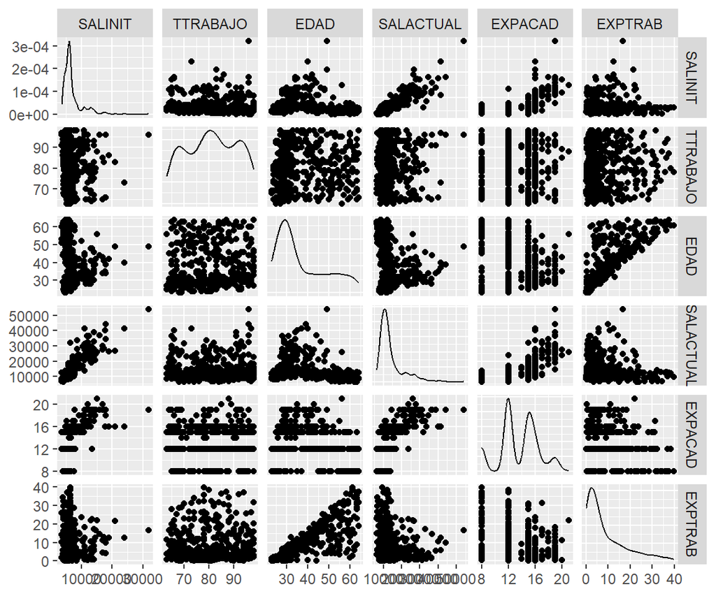

```r
library(GGally)

df %>%
  ggpairs(
    data = .,
    columns = everything(.),
    upper = list(continuous = "points")
  )
```

# 6. Cálculo de Distancia de Mahalanobis y gráfico de barras

```r
dfDist1 <- df %>%
  mutate(DistMaha1 = mahalanobis(., center = colMeans(.), cov = cov(.)))
```

Se grafica mediante un gráfico de barras

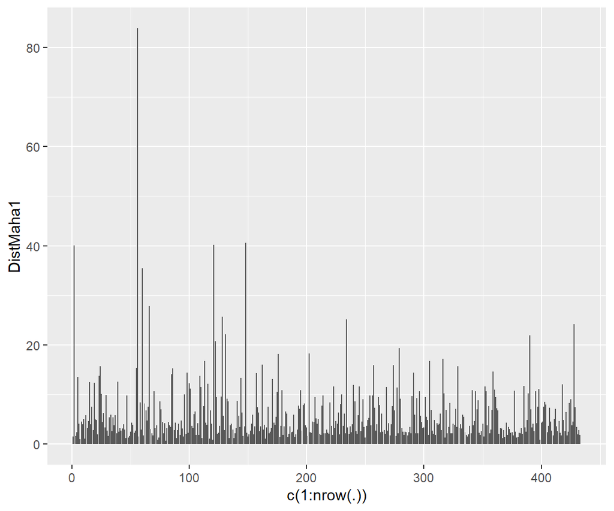

```r
dfDist1 %>%
  ggplot(
    data = .,
    mapping = aes(x = c(1:nrow(.)), y = DistMaha1)
  ) +
  geom_bar(stat = "identity")
```